# Mineração de Dados 5

Os tópicos abordados serão:

- encadeamento de funções: operador *pipe*;
- análise de *cluster*: medidas de dissimilaridade, clusterização hierárquica e dendograma, *k-means*;
- árvores de regressão e árvores de classificação.

Vamos instalar os pacotes necessários.

```r
install.packages("magrittr")   # pacote para utilização do operador pipe e outras funções de encadeamento
install.packages("tidyverse")   # pacote com que engloba vários pacotes para ciência de dados; também permite o uso do operador pipe
install.packages("dendextend")   # pacote para dendogramas
install.packages("rpart")   # pacote para ajuste de árvores de regressão e classificação
install.packages("rpart.plot")  # melhorias gráficas para árvores de regressão e classificação
install.packages("rattle")  # mais opções gráficas para árvores de regressão e classificação
```

Vamos utilizar também os pacotes `ggplot2` e `stringr`, mas eles fazem parte do `tidyverse`; e o pacote `factoextra`, mas este já foi instalado anteriormente.

# Operador *pipe*

- O operador *pipe*, `%>%`, é uma das mudanças mais recentes no *R* e permite o encadeamento de funções de uma maneira que pode ser mais compreensível e lógica.
- O operador surgiu no pacote `magrittr` (Bache e Wickham 2020), mas diversos outros pacotes já o utilizam.
- Entre eles, o pacote `dplyer` (Wickham et al. 2020), que fornece uma gramática própria para se trabalhar com banco de dados. Mais informações em https://dplyr.tidyverse.org/.
- Pacotes como `dplyr`, `ggplot2` (Wickham 2016) e `stringr` (Wickham 2019) fazem parte do `tidyverse` (Wickham et al. 2019), uma coleção de pacotes para ciência de dados.
- Na lógica do *pipe*, uma função do tipo `f(x)` é escrita como `x %>% f`.
- Uma função `f(x,y)` é escrita como `x %>% f(y)`.

### Exemplos (operações com *pipe*)

Vamos chamar o pacote `magritter` e ver alguns exemplos simples do uso do operador *pipe*.

```r
library("magrittr")
```

```r
log(10)   # lógica regular
```

```
## [1] 2.302585
```

```r
10 %>% log   # lógica do pipe
```

```
## [1] 2.302585
```

```r
set.seed(27824)
x <- rexp(10,1/2)   # sorteando valores da distribuição exponencial
x
```

```
##  [1] 0.02644677 2.65551515 0.25799916 0.33391999 0.99282782 0.62464293
##  [7] 1.61593847 4.15898428 0.25670046 0.31285172
```

```r
sqrt(var(x))   # lógica regular
```

```
## [1] 1.33559
```

```r
x %>% var %>% sqrt   # lógica do pipe
```

```
## [1] 1.33559
```

```r
x <- c(3,4,5,6,7,8)
sum((x/3)^2) + 5   # lógica regular
```

```
## [1] 27.11111
```

```r
x %>% divide_by(3) %>% raise_to_power(2) %>% sum %>% add(5)   # lógica do pipe
```

```
## [1] 27.11111
```

Para ver mais *aliases* como `divided_by`, podemos chamar, por exemplo, `help("divided_by")`.

Quando o objeto ao qual a funçao é aplicada não for o primeiro argumento da função, podemos utilizar um ponto em seu lugar (*argument place holder*).

```r
round(pi,4)   # lógica regular
```

```
## [1] 3.1416
```

```r
4 %>% round(pi,.)
```

```
## [1] 3.1416
```

Vamos considerar o conjunto de dados `beaver2` do pacote `base` do *R* para exemplificar outros usos do oerador *pipe*.

```r
?beaver2
head(beaver2)
```

```r
attach(beaver2)   # lógica regular
beaver2 %>% attach   # lógica do pipe
```

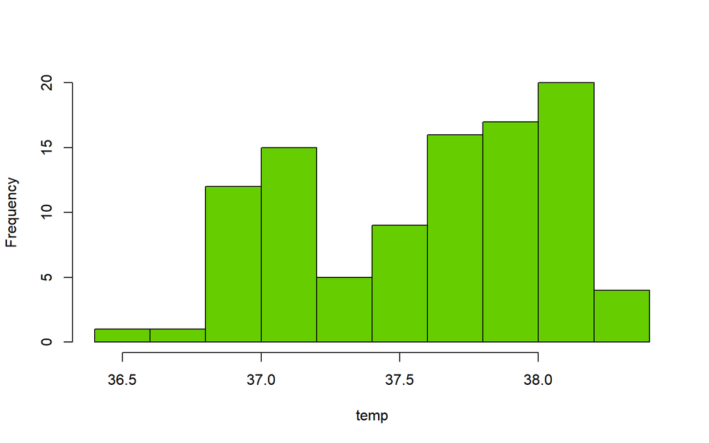

```r
hist(temp,col="chartreuse3",main="")   # lógica regular
```

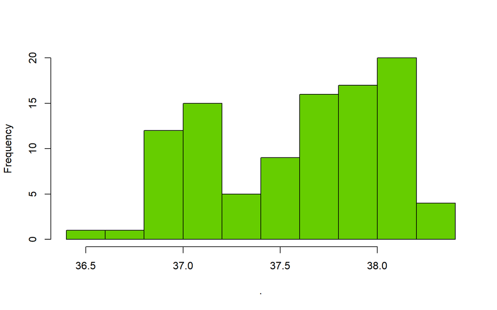

```r
temp %>% hist(col="chartreuse3",main="")   # lógica do pipe
```

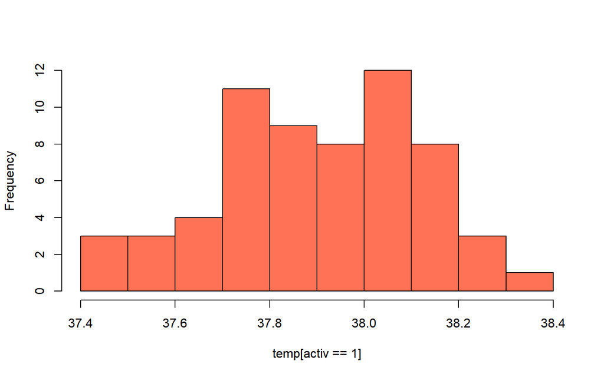

```r
hist(temp[activ==1],col="coral1",main="")   # lógica regular
```

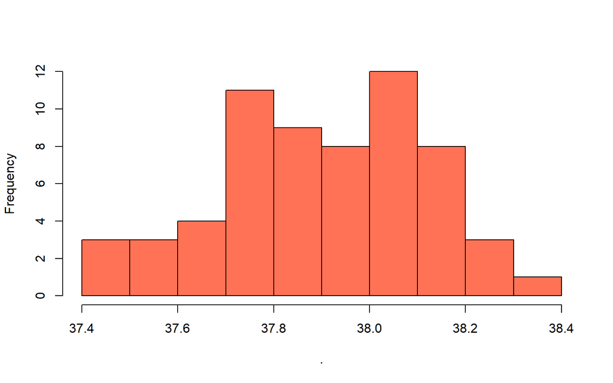

```r
temp %>% extract(activ==1) %>% hist(col="coral1",main="")   # lógica do pipe
```

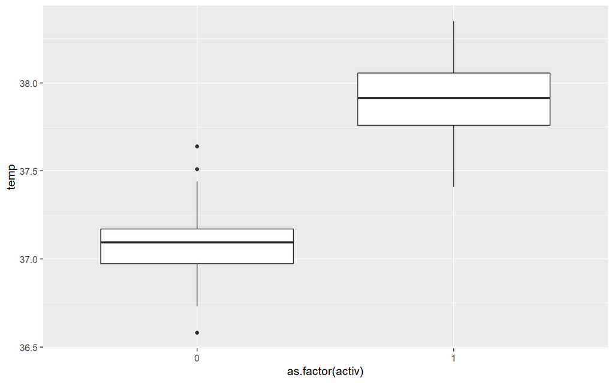

```r
library(ggplot2)
ggplot(beaver2,aes(y=temp,x=as.factor(activ))) + geom_boxplot()   # lógica regular
```

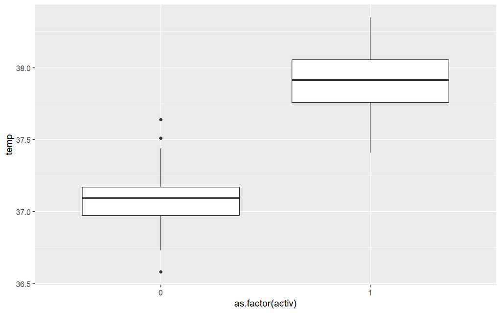

```r
beaver2 %>% ggplot(aes(y=temp,x=as.factor(activ))) + geom_boxplot()   # lógica do pipe
```

# Análise de *cluster*

- **Análise de *cluster*** ou **clusterização** é o processo de particionar os objetos de um banco de dados em grupos, também chamados de *clusters*.
- Os *clusters* são selecionados de forma que os objetos que pertençam a ele tenham características similares.
- Análise de *cluster* é importante para diversas áreas. Por exemplo, cosumidores podem ser agrupados de acordo com suas caracterísicas de consumo; plantas podem ser agrupadas de acordo com suas caractertísticas físicas; empresas podem ser agrupadas de acordo com seus gastos, ganhos.
- Existem variados métodos de clusterização que podem produzir diferentes *clusters* para um mesmo problema, mas todos têm a mesma finalidade: agrupar objetos similares em grupos.

## Clusterização hierárquica

- O tipo mais comum de clusterização hierárquica é o **método aglomerativo**.
- Inicia-se com cada registro do banco de dados formando seu próprio agrupamento; em seguida os registros são unidos em grupos de forma gradual até que todos pertençam a um único grupo.
- Especificamente, seguimos os seguintes passos:
  1. Inicialmente, cada um dos $n$ registros do banco de dados representa seu próprio *cluster*;
  2. calcula-se uma **medida de dissimilaridade** de cada par de registros;
  3. O par com a menor medida de dissimilaridade são unidos em um *cluster* de forma que tenha-se $n-1$ *clusters*;
  4. para $i=n-1,\dots,1$, examina-se todos os pares de *cluster*, calcula-se a medida de dissimilaridade entre eles e junta-se os dois com menor medida;
  5. repete-se o procedimento para os $i-1$ *clusters* restantes.
- Entre algumas medidas de dissimilaridade para variáveis quantitativas está a **distância euclidiana**.
- Seja ${\bf x}_1,\dots,{\bf x}_n$ de forma que ${\bf x}_{j}=(x_{j1},\dots,x_{jp})$ são os valores das variáveis (registros) para o objeto $j$.
- A distância euclidiana entre ${\bf x}_i$ e ${\bf x}_j$ é dada por
  $$d_{ij} = ||{\bf x}_i - {\bf x}_j||=\sqrt{(x_{i1} - x_{j1})^2 + \cdots + (x_{ip} - x_{jp})^2}.$$
- Pode-se trabalhar também com **medidas de similaridade**. Uma delas é baseada correlação entre ${\bf x}_i$ e ${\bf x}_j$.
- Seja $r_{ij}$ o valor da correlação. Neste caso, considera-se como medida de similaridade $r_{ij}^2$.
- Pode-se considerar como medida de dissimilaridade, neste caso, é $1-r_{ij}^2$.
- Mais medidas de dissimilaridade podem ser vistas em Shmueli et al. (2017).

### Exemplo (medidas de dissimilaridade)

Vamos gerar um conjunto de pontos no plano cartesiano para ilustramos o cálculos das medidas.

```r
set.seed(12000)
xc1 <- runif(10,0.5,1)   # gerando pontos em grupos
yc1 <- runif(10,0.5,1)
xc2 <- runif(10,-1,-0.5)
yc2 <- runif(10,-1,-0.5)
xc3 <- runif(10,-0.5,0)
yc3 <- runif(10,-0.5,0)
x <- c(xc1,xc2,xc3)
y <- c(yc1,yc2,yc3)
clu <- rep(c("A","B","C"),c(10,10,10))
lab <- 1:30
dados <- data.frame(x,y,clu,lab)
```

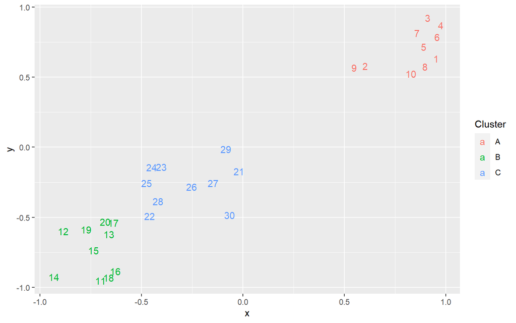

```r
library("ggplot2")
ggplot(dados,aes(x,y,col=clu)) + geom_point(pch="") + scale_color_discrete(name="Cluster") + geom_text(aes(x=x,y=y,label=lab))
```

Vamos calcular a distância euclidiana e ver qual é a distância mínima.

```r
d1 <- dist(dados[,-c(3,4)])   # calcula a distância entre os pontos
```

Por meio do pacote `factoextra` (Kassambara e Mundt 2020), podemos visualizar a matriz de disntâncias entre todos os pontos.

```r
library("factoextra")
```

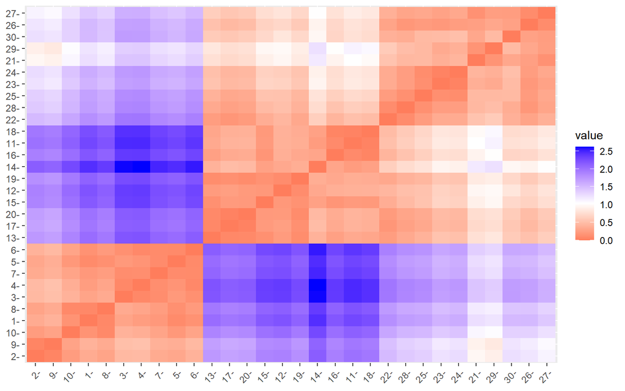

```r
fviz_dist(d1)
```

Vamos verificar qual é a menor distância para iniciar o algoritmo.

```r
d2 <- as.matrix(d1) + diag(100,30)   # tranformando d1 em matriz e somando um valor grande na diagonal
which(d2==min(d2),arr.ind=TRUE)   # retornado a posição da distância mínima
```

```
##    row col
## 20  20  17
## 17  17  20
```

```r
min(d1)   # distância mínima
```

```
## [1] 0.04059117
```

Os pontos 20 e 17 são os mais próximos, segundo a distância euclidiana. Logo, no primeiro passo do algoritmo, eles formarão um cluster.

- Podemos medir a distância entre dois pontos como medida de dissimilaridade, mas como podemos medir a dissimilaridade entre *clusters*?
- Há alguma maneiras (*linkages*) de se calcular a dissimilaridade:
  - *complete*: considera o valor máximo das medidas de dissimilaridade entre todos os pares formados por um elemento de cada *cluster*;
  - *single*: considera o valor mínimo das medidas de dissimilaridade entre todos os pares formados por um elemento de cada *cluster*;
  - *average*: considera o valor médio das medidas de dissimilaridade entre todos os pares formados por um elemento de cada *cluster*;
  - *centroid*: considera a medida de dissimilaridade entre os centróides de cada *cluster*.
- Detalhes podem ser vistos em James et al. (2013).

### Exemplo (dendrograma)

O **dendrograma** é uma representação gráfica da clusterização hierárquica.

Vamos fazer um dendograma para os dados dos exemplo. Para isto, utilizaremos a função `hclust()`, que gera as saídas do algoritmo de clusterização hieráquica.

O número de *clusters* depende de onde “cortamos” o dendrograma.

A altura das linhas correspondem à medida de dissimilaridade entre os valores/*clusters*.

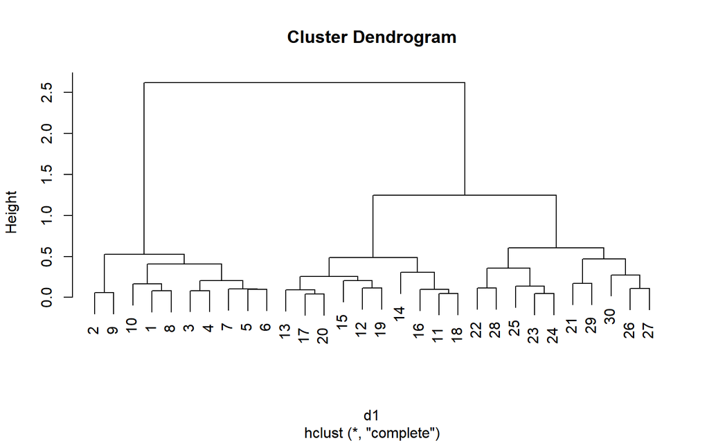

```r
hc <- hclust(d1,method="complete")
plot(hc)
```

Para termo mais opções gráficas, podemos transformar o objeto originado a partir da função `hclust()` e transformá-lo em um objeto dendrograma.

```r
hcd <- as.dendrogram(hc)
```

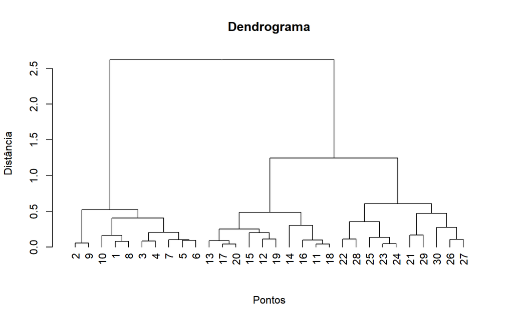

```r
plot(hcd,main="Dendrograma",ylab="Distância",xlab="Pontos")
```

Para termos ainda mais opções gráficas, vamos chamar o pacote `dendextend` (Galili 2015).

```r
library("dendextend")
```

Vamos colorir os *clusters* de acordo com o número desejado.

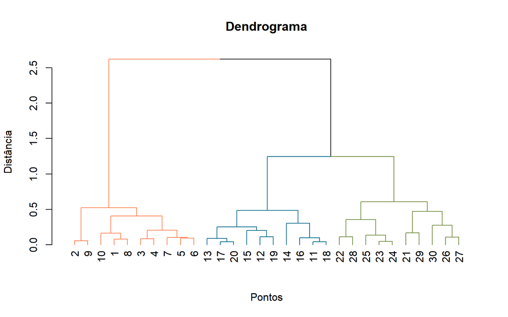

```r
plot(color_branches(hcd,k=3,col=c("coral","deepskyblue4","darkolivegreen4")),main="Dendrograma",ylab="Distância",xlab="Pontos")
```

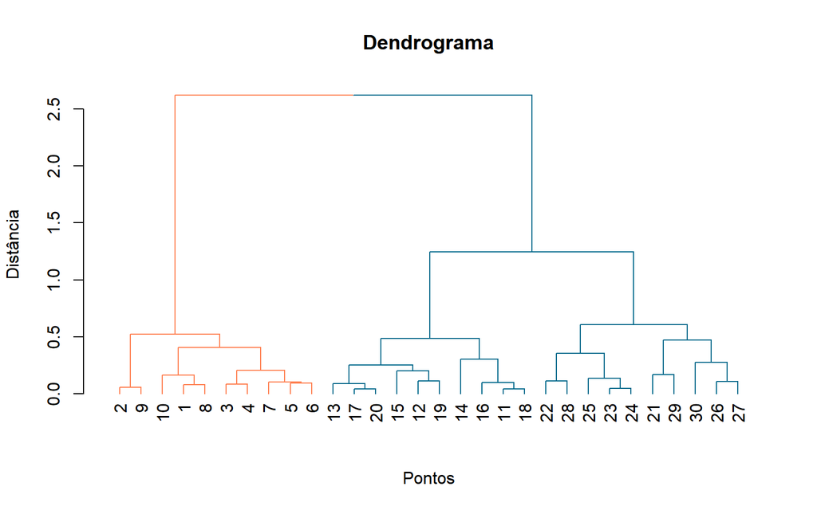

```r
plot(color_branches(hcd,k=2,col=c("coral","deepskyblue4")),main="Dendrograma",ylab="Distância",xlab="Pontos")
```

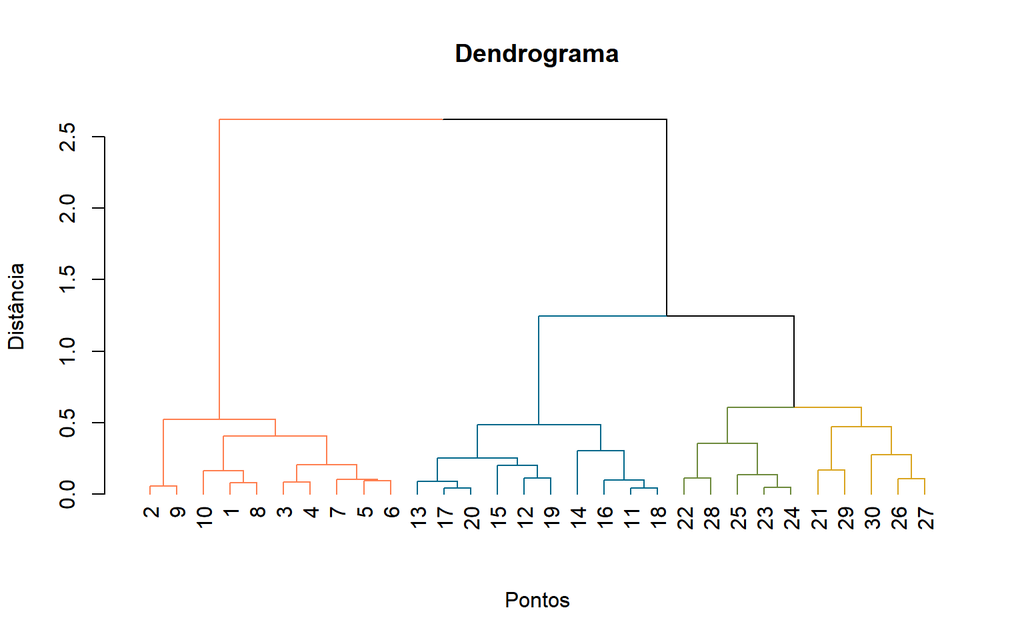

```r
plot(color_branches(hcd,k=4,col=c("coral","deepskyblue4","darkolivegreen4","goldenrod")),main="Dendrograma",ylab="Distância",xlab="Pontos")
```

Para obter os pontos em cada *cluster*, podemos utilizar a funça `cutree()`.

```r
grupos <- cutree(hcd,k=3)   # escolhendo o número de clusters
grupos
```

```
##  1  2  3  4  5  6  7  8  9 10 11 12 13 14 15 16 17 18 19 20 21 22 23 24 25 26
##  1  1  1  1  1  1  1  1  1  1  2  2  2  2  2  2  2  2  2  2  3  3  3  3  3  3
## 27 28 29 30
##  3  3  3  3
```

```r
grupos2 <- cutree(hcd,h=2)   # escolhendo a altura do corte no dendrograma
grupos2
```

```
##  1  2  3  4  5  6  7  8  9 10 11 12 13 14 15 16 17 18 19 20 21 22 23 24 25 26
##  1  1  1  1  1  1  1  1  1  1  2  2  2  2  2  2  2  2  2  2  2  2  2  2  2  2
## 27 28 29 30
##  2  2  2  2
```

## *k-means*

- O *k-means* é um método de clusterização não hierárquico.
- Diferentemente do método hierárquico, o número de *clusters* - denotado por $k$ - deve ser pré-determinado e o algoritmo é iterativo.
- Os registros são atribuídos a *clusters* de forma que se minimize uma medidade de dispersão.
- É comum considerar como medida de dispersão a soma das distâncias euclidianas de cada registro ou a soma dos quadrados das distâncias euclidianas.
- Seja $\mu_i$ o centróide do *cluster* $C_i$. Vamos denotar a distância de um ponto ${\bf x}$ ao centróide do seu *cluster* como $d({\bf x},\mu_i)$.
- A medida de dispersão a ser minmizada é dada por
  $$E = \sum_{i=k}\sum_{{\bf x}\in C_i} d({\bf x},\mu_i).$$
- Especificamente, seguimos os seguintes passos:
  1. Inicialmente, seleciona-se $k$ *clusters*;
  2. a cada passo, cada ponto é tranferido para o *cluster* mais próximo, de acordo com o centróide;
  3. recalcula-se as distâncias dos pontos ao centróide do *cluster* o qual ele foi atribuído;
  4. para-se quando não houver mais mudanças (*clusters* não mudarem).

### Exemplo (*k-means*)

Podemos rodar o algoritmo para os dados do exemplo anterior por meio da função `kmeans()`.

Vamos considerar diferentes valores de $k$, como fizemos no caso do dendrograma.

```r
k2 <- kmeans(dados[,1:2],2)
k3 <- kmeans(dados[,1:2],3)
k4 <- kmeans(dados[,1:2],4)
k2
```

```
## K-means clustering with 2 clusters of sizes 10, 20
##
## Cluster means:
##            x          y
## 1  0.8422183  0.6985548
## 2 -0.5037618 -0.4965567
##
## Clustering vector:
##  [1] 1 1 1 1 1 1 1 1 1 1 2 2 2 2 2 2 2 2 2 2 2 2 2 2 2 2 2 2 2 2
##
## Within cluster sum of squares by cluster:
## [1] 0.3801929 3.0175358
##  (between_SS / total_SS =  86.4 %)
##
## Available components:
##
## [1] "cluster"      "centers"      "totss"        "withinss"     "tot.withinss"
## [6] "betweenss"    "size"         "iter"         "ifault"
```

```r
k3
```

```
## K-means clustering with 3 clusters of sizes 10, 10, 10
##
## Cluster means:
##            x          y
## 1  0.8422183  0.6985548
## 2 -0.2774340 -0.2622940
## 3 -0.7300896 -0.7308194
##
## Clustering vector:
##  [1] 1 1 1 1 1 1 1 1 1 1 3 3 3 3 3 3 3 3 3 3 2 2 2 2 2 2 2 2 2 2
##
## Within cluster sum of squares by cluster:
## [1] 0.3801929 0.5199396 0.3755303
##  (between_SS / total_SS =  94.9 %)
##
## Available components:
##
## [1] "cluster"      "centers"      "totss"        "withinss"     "tot.withinss"
## [6] "betweenss"    "size"         "iter"         "ifault"
```

```r
k4
```

```
## K-means clustering with 4 clusters of sizes 9, 5, 10, 6
##
## Cluster means:
##            x          y
## 1 -0.2571528 -0.2368910
## 2 -0.7325231 -0.8862127
## 3  0.8422183  0.6985548
## 4 -0.6830409 -0.5613417
##
## Clustering vector:
##  [1] 3 3 3 3 3 3 3 3 3 3 2 4 4 2 2 2 4 2 4 4 1 4 1 1 1 1 1 1 1 1
##
## Within cluster sum of squares by cluster:
## [1] 0.42484245 0.08648163 0.38019287 0.11318508
##  (between_SS / total_SS =  96.0 %)
##
## Available components:
##
## [1] "cluster"      "centers"      "totss"        "withinss"     "tot.withinss"
## [6] "betweenss"    "size"         "iter"         "ifault"
```

Novamente, podemos utilizar as funções do pacote `factoextra` para visualizarmos os resultados.

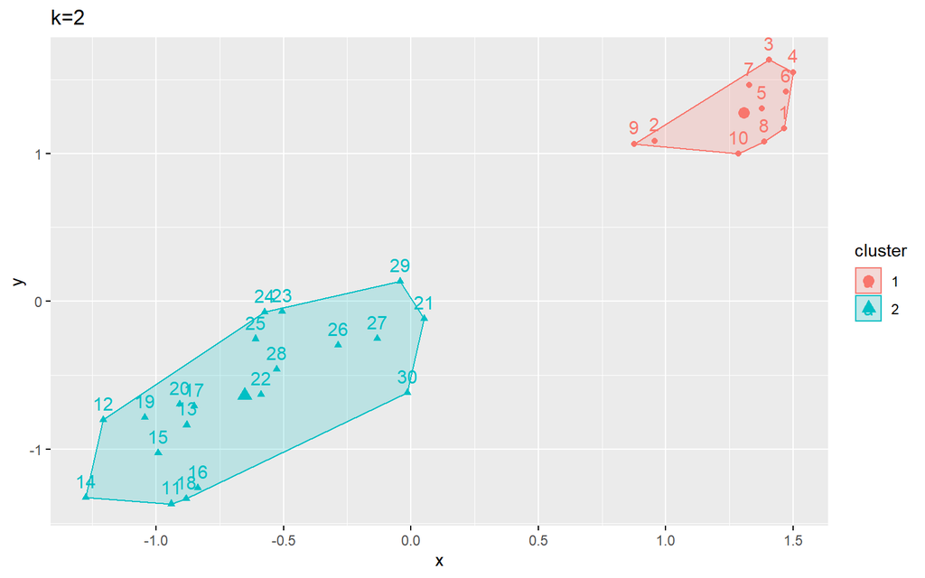

```r
fviz_cluster(k2,data=dados[,1:2]) + labs(x="x",y="y",title="k=2")
```

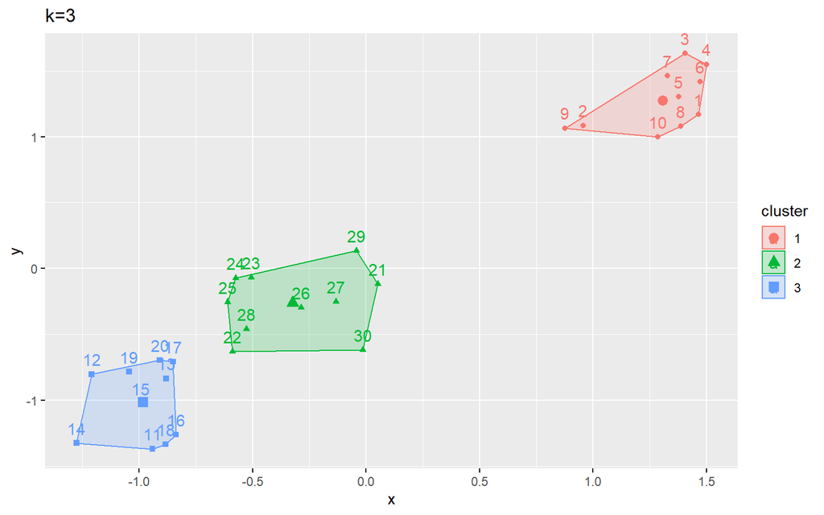

```r
fviz_cluster(k3,data=dados[,1:2]) + labs(x="x",y="y",title="k=3")
```

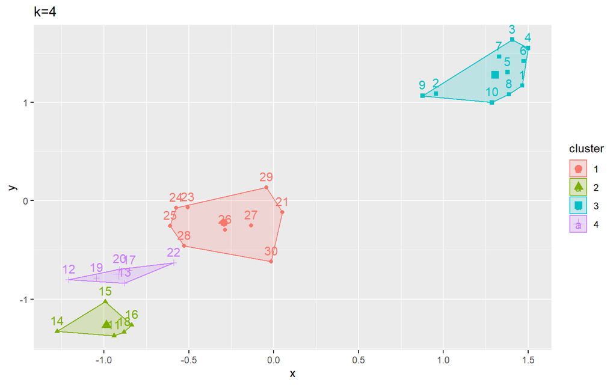

```r
fviz_cluster(k4,data=dados[,1:2]) + labs(x="x",y="y",title="k=4")
```

- Não se garante que o algortimo convirja para o ótimo global, pois ele pode ficar preso em um ótimo local.
- É comum rodar-se o algoritmo várias vezes começando de configurações iniciais de *cluster* diferentes.

# Exemplo 7 - Serviços de utilidade pública (2)

- Vamo voltar ao banco de dados das 22 empresas de utilidade pública dos Estados Unidos disponíveis em Shmueli et al. (2017).
- As variáveis são:
  - *Fixed - fixed-charge covering ratio (income/debt);*
  - *RoR - rate of return on capital;*
  - *Cost - cost per kilowatt capacity in place; Load = annual load factor;*
  - *Demand - peak kilowatthour demand growth from 1974 to 1975;*
  - *Sales - sales (kilowatthour use per year);*
  - *Nuclear - percent nuclear;*
  - *Fuel Cost - total fuel costs (cents per kilowatthour);*

## Importando o banco de dados

### Arquivo com extensão .txt separado por tabulação

Vamos importar a base de dados.

```r
uti <- read.csv("http://im.ufrj.br/~joao/cienciadedados/utilities.txt",sep="\t")
head(uti)   # vislumbre dos dados
names(uti)   # # nomes das colunas do objeto (variáveis)
```

```
##                          Company Fixed  RoR Cost Load Demand Sales Nuclear
## 1         Arizona Public Service  1.06  9.2  151 54.4    1.6  9077     0.0
## 2              Boston Edison Co.  0.89 10.3  202 57.9    2.2  5088    25.3
## 3          Central Louisiana Co.  1.43 15.4  113 53.0    3.4  9212     0.0
## 4        Commonwealth Edison Co.  1.02 11.2  168 56.0    0.3  6423    34.3
## 5   Consolidated Edison Co. (NY)  1.49  8.8  192 51.2    1.0  3300    15.6
## 6      Florida Power & Light Co.  1.32 13.5  111 60.0   -2.2 11127    22.5
## 7          Hawaiian Electric Co.  1.22 12.2  175 67.6    2.2  7642     0.0
## 8                Idaho Power Co.  1.10  9.2  245 57.0    3.3 13082     0.0
## 9         Kentucky Utilities Co.  1.34 13.0  168 60.4    7.2  8406     0.0
## 10    Madison Gas & Electric Co.  1.12 12.4  197 53.0    2.7  6455    39.2
## 11              Nevada Power Co.  0.75  7.5  173 51.5    6.5 17441     0.0
## 12      New England Electric Co.  1.13 10.9  178 62.0    3.7  6154     0.0
## 13     Northern States Power Co.  1.15 12.7  199 53.7    6.4  7179    50.2
## 14   Oklahoma Gas & Electric Co.  1.09 12.0   96 49.8    1.4  9673     0.0
```

[output cut: 31 more lines]

```
## [1] "Company"   "Fixed"     "RoR"       "Cost"      "Load"      "Demand"
## [7] "Sales"     "Nuclear"   "Fuel.cost"
```

## Clusterização hierárquica

- É aconselhável, antes de prosseguir com o método, que os valores das variáveis sejam padronizados, uma vez que as escalas muito diferentes pode influenciar as medidas de distâncias.

### Dendrograma para os dados das empresas de serviço público

Vamos encurtar os nomes para fins de visualização, vamos nomear as linhas do *data frame* encurtar o nome das empresas utilizando a função `word()` do pacote `stringr` (Wickham 2019).

```r
library("stringr")
uti2 <- uti[,-1]    # retirando a coluna de nomes
nomes <- word(uti[,1])   # pegando a primeira palavra
nomes[c(12,17,18)] <- paste(nomes[c(12,17,18)],word(uti[c(12,17,18),1],2))   # acrescentando a segunda palavra em alguns nomes
nomes
```

```
##  [1] "Arizona"      "Boston"       "Central"      "Commonwealth" "Consolidated"
##  [6] "Florida"      "Hawaiian"     "Idaho"        "Kentucky"     "Madison"
## [11] "Nevada"       "New England"  "Northern"     "Oklahoma"     "Pacific"
## [16] "Puget"        "San Diego"    "The Southern" "Texas"        "Wisconsin"
## [21] "United"       "Virginia"
```

```r
row.names(uti2) <- nomes   # nomeando as linhas do data frame
```

Vamos primeiramente padronizar os valores do banco de dados e calcular a matriz de distâncias euclidianas.

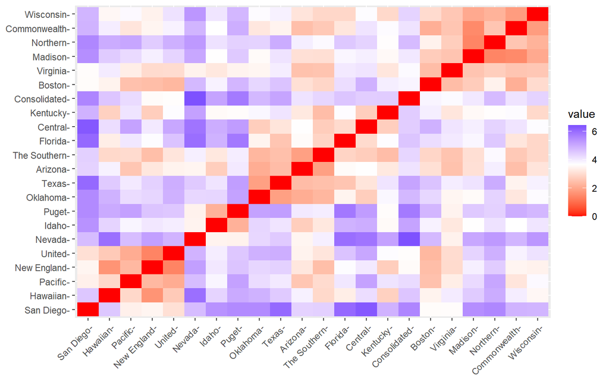

```r
uti3 <- apply(uti2,MARGIN=2,FUN="scale")
row.names(uti3) <- nomes   # nomeando as linhas
d <- dist(uti3)
fviz_dist(d)
```

Agora faremos a clusterização e visualizaremos os resultados.

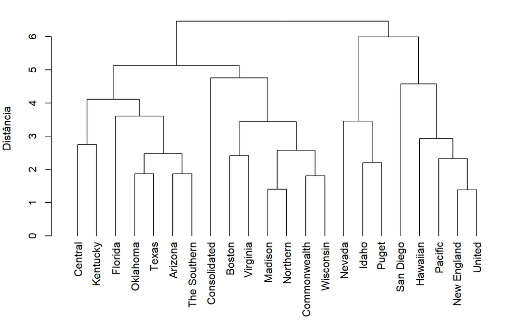

```r
cores <- c("#ff8000","#1a1aff","#669900","#e6e600","#cc00cc")
hc <- hclust(d,method="complete")
hcd <- as.dendrogram(hc)
par(mar=c(6,4,1,1))
plot(hcd,ylab="Distância")
```

Vamos selecionar alguns valores para o número de *clusters*.

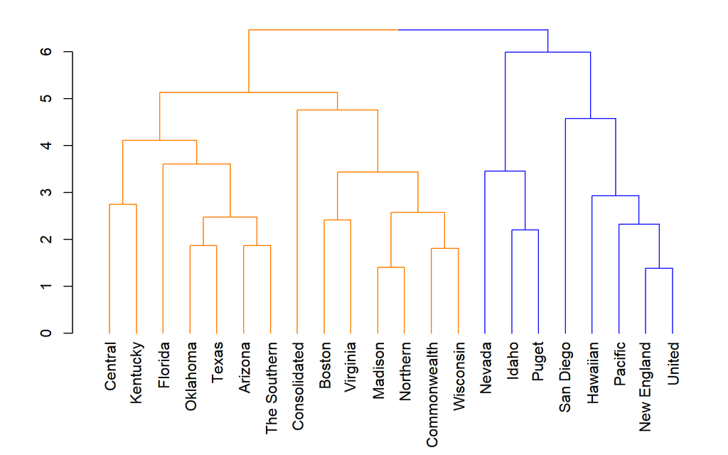

```r
par(mar=c(6,4,1,1))
k2 <- color_branches(hcd,k=2,col=cores[1:2])
k3 <- color_branches(hcd,k=3,col=cores[1:3])
k4 <- color_branches(hcd,k=4,col=cores[1:4])
k5 <- color_branches(hcd,k=5,col=cores)
plot(k2)
```

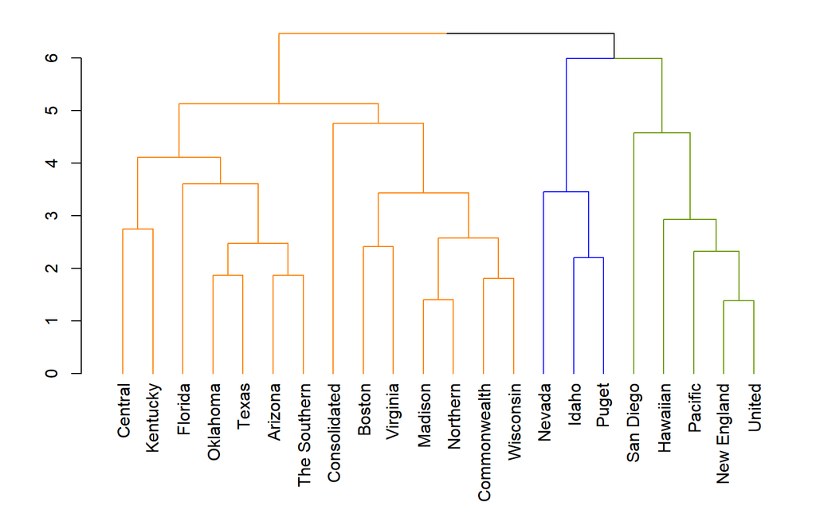

```r
plot(k3)
```

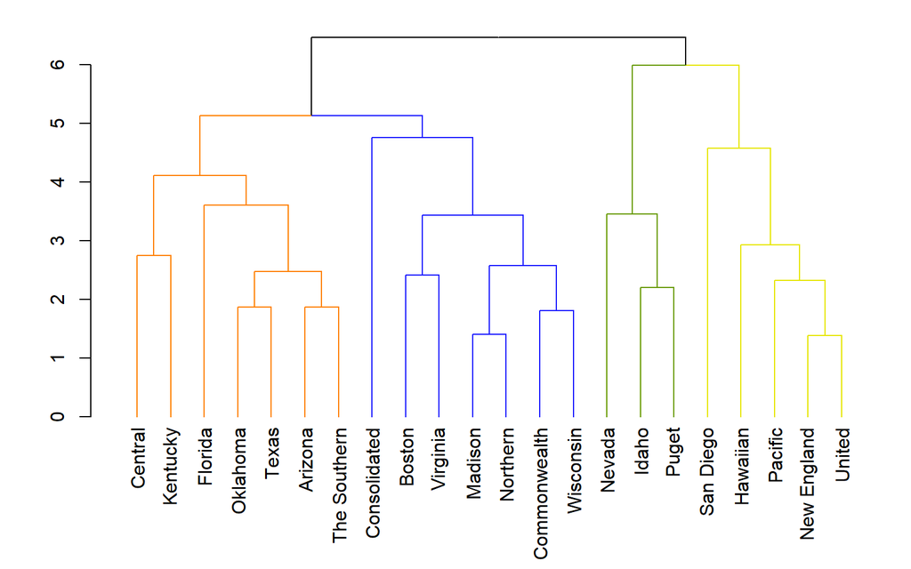

```r
plot(k4)
```

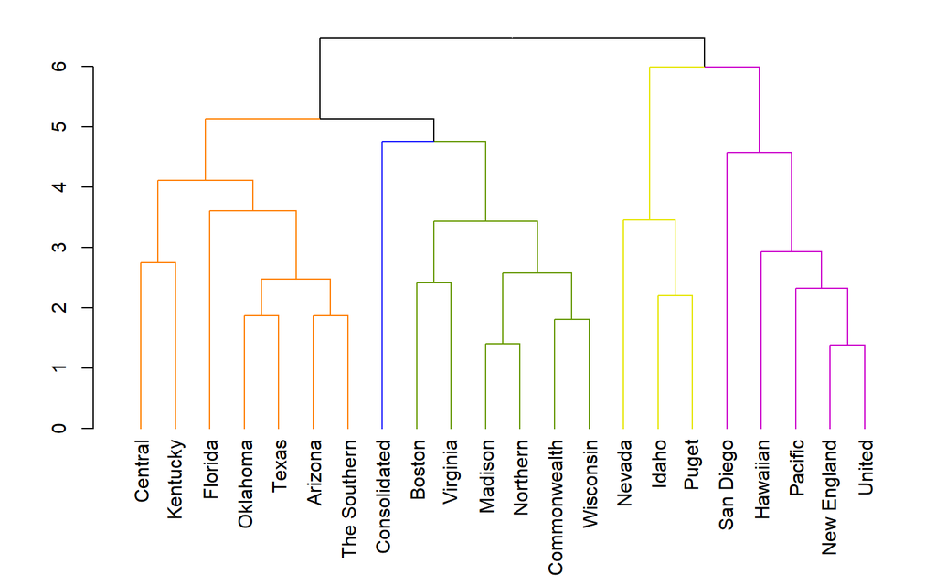

```r
plot(k5)
```

O pacote `dendextend` possui algumas funções que permitem editarmos alguns aspectos do dendrograma, como a função `set()`.

Para utilizá-la, é necessário o uso do operador *pipe*.

Vamos colorir e colocar pontos nas “folhas” do dendrograma.

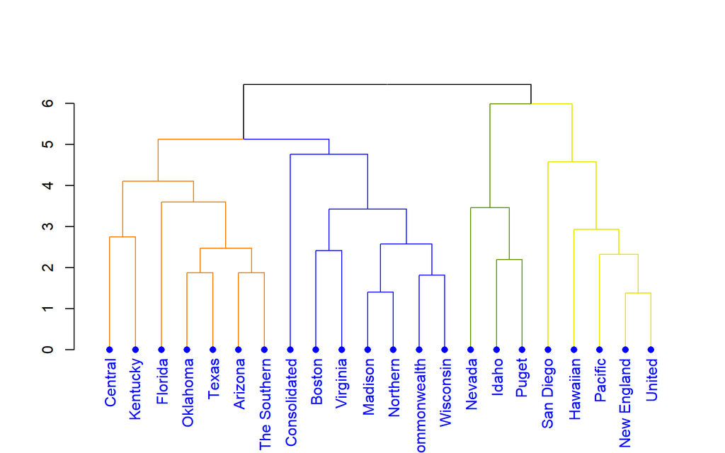

```r
hcd %>% set("leaves_col","blue") %>% set("leaves_pch",16) %>% set("labels_col","blue") %>% branches_color(k=4,col=cores[1:4]) %>% plot
```

Vamos ver o que acontece se utilizarmos outro método de *linkage*: *average*.

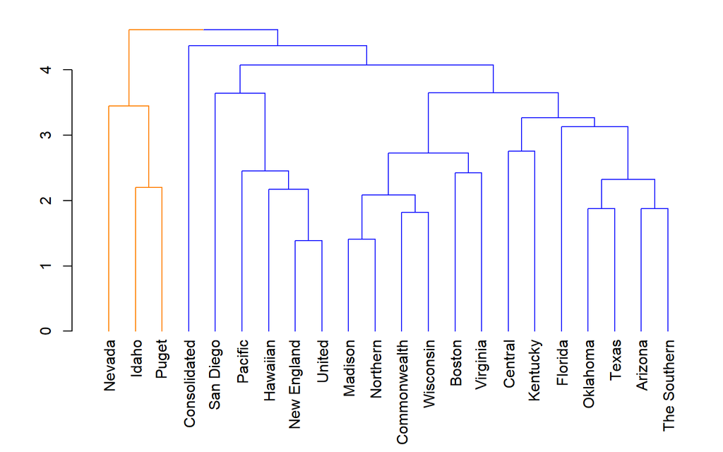

```r
hc <- hclust(d,method="average")
hcd <- as.dendrogram(hc)
par(mar=c(6,4,1,1))
k2 <- color_branches(hcd,k=2,col=cores[1:2])
k3 <- color_branches(hcd,k=3,col=cores[1:3])
k4 <- color_branches(hcd,k=4,col=cores[1:4])
k5 <- color_branches(hcd,k=5,col=cores)
plot(k2)
```

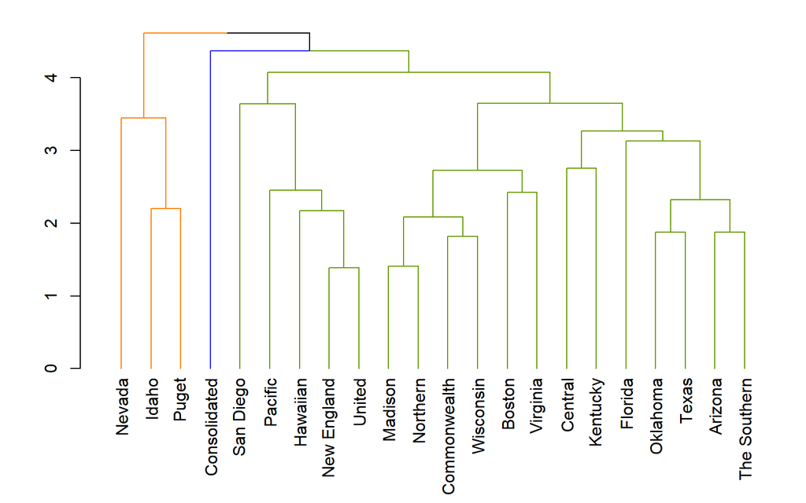

```r
plot(k3)
```

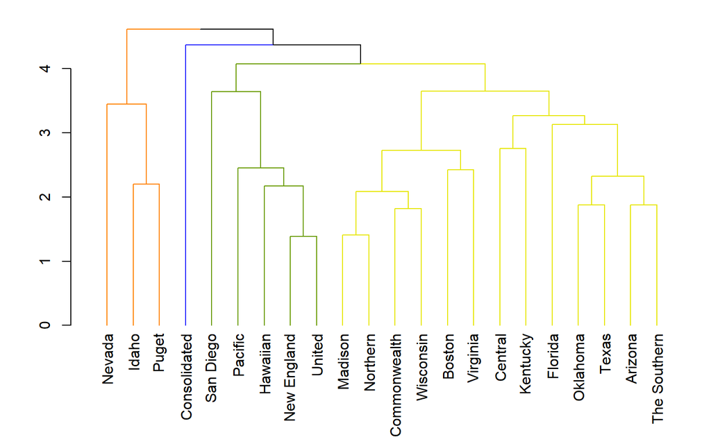

```r
plot(k4)
```

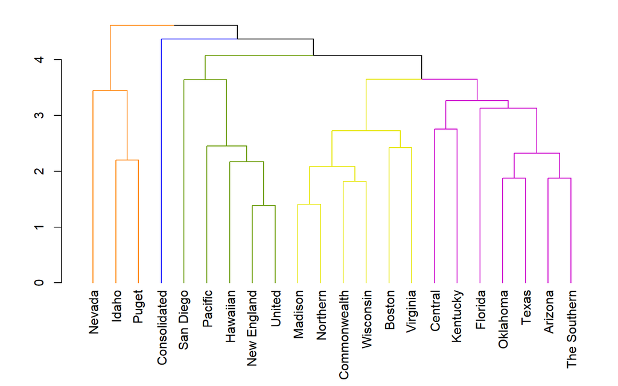

```r
plot(k5)
```

Agora vamos utilizar o método *centroid*.

Tal método podem levar a inversões não desejadas, o que torna difícil a interpretação.

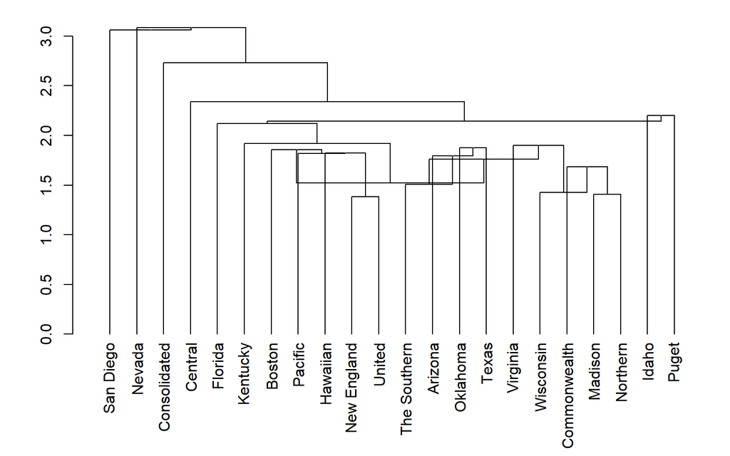

```r
hc <- hclust(d,method="centroid")
hcd <- as.dendrogram(hc)
par(mar=c(6,4,1,1))
plot(hcd)
```

Podemos construir também um dendrograma associado a um mapa de calor, com o objetivo de visualizar similaridades entre as empresas.

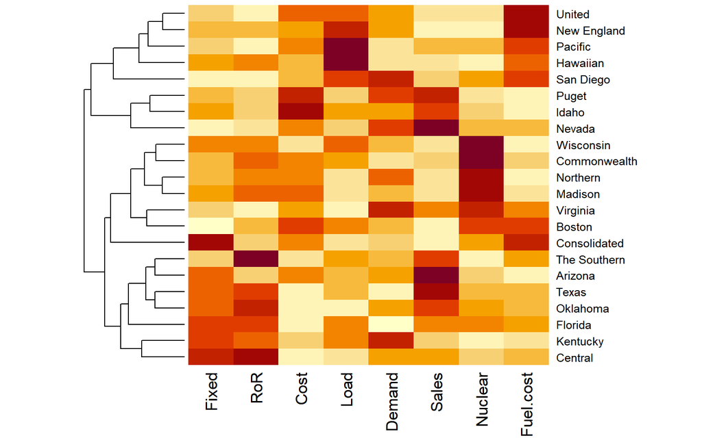

```r
hc <- hclust(d,method="complete")
hcd <- as.dendrogram(hc)
heatmap(uti3,Rowv=hcd,Colv=NA)
```

Por fim, vamos utilizar o comando `cutree` para distribuir as empresas entre os *clusters*.

```r
cutree(hcd,k=4)
```

```
##      Arizona       Boston      Central Commonwealth Consolidated      Florida
##            1            2            1            2            2            1
##     Hawaiian        Idaho     Kentucky      Madison       Nevada  New England
##            3            4            1            2            4            3
##     Northern     Oklahoma      Pacific        Puget    San Diego The Southern
##            2            1            3            4            3            1
##        Texas    Wisconsin       United     Virginia
##            1            2            3            2
```

## *k-means*

- Assim como para a clusterização hierárquica, é aconselhável que os valores das variáveis sejam padronizados antes de rodarmos o algoritmo.

### *k-means* para os dados das empresas de serviço público

Vamos escolher alguns valores diferentes para o número de *clusters*.

```r
k2 <- kmeans(uti3,2)
k3 <- kmeans(uti3,3)
k4 <- kmeans(uti3,4)
k5 <- kmeans(uti3,5)
k2
```

```
## K-means clustering with 2 clusters of sizes 17, 5
##
## Cluster means:
##        Fixed        RoR      Cost       Load     Demand      Sales    Nuclear
## 1 -0.1528826 -0.3019275  0.381161  0.1501376  0.2453213 -0.1506017  0.1313657
## 2  0.5198010  1.0265533 -1.295947 -0.5104679 -0.8340925  0.5120458 -0.4466434
##     Fuel.cost
## 1  0.09336444
## 2 -0.31743910
##
## Clustering vector:
##      Arizona       Boston      Central Commonwealth Consolidated      Florida
##            1            1            2            1            1            2
##     Hawaiian        Idaho     Kentucky      Madison       Nevada  New England
##            1            1            1            1            1            1
##     Northern     Oklahoma      Pacific        Puget    San Diego The Southern
##            1            2            1            1            1            2
##        Texas    Wisconsin       United     Virginia
##            2            1            1            1
##
## Within cluster sum of squares by cluster:
## [1] 123.58244  15.15613
##  (between_SS / total_SS =  17.4 %)
##
## Available components:
##
## [1] "cluster"      "centers"      "totss"        "withinss"     "tot.withinss"
## [6] "betweenss"    "size"         "iter"         "ifault"
```

```r
k3
```

```
## K-means clustering with 3 clusters of sizes 8, 7, 7
##
## Cluster means:
##        Fixed         RoR       Cost       Load      Demand      Sales
## 1 -0.5370456 -0.75705270  0.5509211  0.6551514  0.45589378  0.2756927
## 2  0.1094503  0.08565221  0.3562720 -0.4111981 -0.03144454 -0.6669373
## 3  0.5043161  0.77955087 -0.9858961 -0.3375463 -0.48957692  0.3518600
##      Nuclear   Fuel.cost
## 1 -0.6461441  0.41813259
## 2  1.2616612 -0.06732906
## 3 -0.5232108 -0.41053676
##
## Clustering vector:
##      Arizona       Boston      Central Commonwealth Consolidated      Florida
##            3            2            3            2            2            3
##     Hawaiian        Idaho     Kentucky      Madison       Nevada  New England
##            1            1            3            2            1            1
##     Northern     Oklahoma      Pacific        Puget    San Diego The Southern
##            2            3            1            1            1            3
##        Texas    Wisconsin       United     Virginia
##            3            2            1            2
##
## Within cluster sum of squares by cluster:
## [1] 58.25276 27.69741 26.50777
##  (between_SS / total_SS =  33.1 %)
##
## Available components:
##
## [1] "cluster"      "centers"      "totss"        "withinss"     "tot.withinss"
## [6] "betweenss"    "size"         "iter"         "ifault"
```

```r
k4
```

```
## K-means clustering with 4 clusters of sizes 4, 1, 7, 10
##
## Cluster means:
##         Fixed        RoR       Cost       Load       Demand      Sales
## 1  0.04557497  0.5742460  0.2383554 -0.2975182 -0.005101929 -0.5853676
## 2  2.03732429 -0.8628882  0.5782326 -1.2950193 -0.718643112 -1.5814284
## 3  0.50431607  0.7795509 -0.9858961 -0.3375463 -0.489576922  0.3518600
## 4 -0.57498366 -0.6890952  0.5369618  0.4847917  0.416608928  0.1459879
##      Nuclear  Fuel.cost
## 1  1.7389316 -0.8356930
## 2  0.2143888  1.6926380
## 3 -0.5232108 -0.4105368
## 4 -0.3507639  0.4523891
##
## Clustering vector:
##      Arizona       Boston      Central Commonwealth Consolidated      Florida
##            3            4            3            1            2            3
##     Hawaiian        Idaho     Kentucky      Madison       Nevada  New England
##            4            4            3            1            4            4
##     Northern     Oklahoma      Pacific        Puget    San Diego The Southern
##            1            3            4            4            4            3
##        Texas    Wisconsin       United     Virginia
##            3            1            4            4
##
## Within cluster sum of squares by cluster:
## [1]  5.830596  0.000000 26.507769 66.868171
##  (between_SS / total_SS =  40.9 %)
##
## Available components:
##
## [1] "cluster"      "centers"      "totss"        "withinss"     "tot.withinss"
## [6] "betweenss"    "size"         "iter"         "ifault"
```

```r
k5
```

```
## K-means clustering with 5 clusters of sizes 1, 5, 7, 3, 6
##
## Cluster means:
##         Fixed        RoR       Cost       Load      Demand      Sales
## 1  2.03732429 -0.8628882  0.5782326 -1.2950193 -0.71864311 -1.5814284
## 2 -0.01133215  0.3313815  0.2189339 -0.3580408  0.16646865 -0.4018738
## 3  0.50431607  0.7795509 -0.9858961 -0.3375463 -0.48957692  0.3518600
## 4 -0.60027572 -0.8331800  1.3389101 -0.4805802  0.99171778  1.8565214
## 5 -0.61834147 -0.6252226  0.2019400  1.1482980  0.05636417 -0.7402978
##      Nuclear  Fuel.cost
## 1  0.2143888  1.6926380
## 2  1.5650384 -0.5954476
## 3 -0.5232108 -0.4105368
## 4 -0.7146294 -0.9657660
## 5 -0.3722028  1.1759426
##
## Clustering vector:
##      Arizona       Boston      Central Commonwealth Consolidated      Florida
##            3            5            3            2            1            3
##     Hawaiian        Idaho     Kentucky      Madison       Nevada  New England
##            5            4            3            2            4            5
##     Northern     Oklahoma      Pacific        Puget    San Diego The Southern
##            2            3            5            4            5            3
##        Texas    Wisconsin       United     Virginia
##            3            2            5            2
##
## Within cluster sum of squares by cluster:
## [1]  0.000000 10.177094 26.507769  9.533522 21.187976
##  (between_SS / total_SS =  59.9 %)
##
## Available components:
##
## [1] "cluster"      "centers"      "totss"        "withinss"     "tot.withinss"
## [6] "betweenss"    "size"         "iter"         "ifault"
```

Para tornar possível a visualização, o comando `fviz_cluster` executa uma análise de componentes principais de forma que os *clusters* são mostrados no plano cartesiano formado pelas primeiras componentes principais.

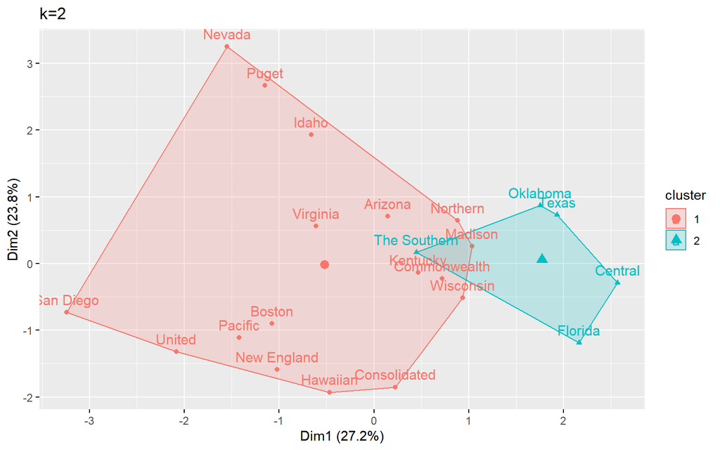

```r
fviz_cluster(k2,data=uti3) + labs(title="k=2")
```